# Assignment 2: Mapping Fire Incidents and FDNY Response Times

##### b) Map of Response Times

Provide a map visualization of response times. Investigate whether the type of property affected (`PROPERTY_USE_DESC`) or fire severity (`HIGHEST_LEVEL_DESC`) play a role here.

```r
# Filter building fires to include only some of the most and least severe
# to keep things manageable - otherwise the whole map floods with dots
some_building_fires <- full_building_fires %>%
  filter(HIGHEST_LEVEL_DESC == "55 - Fifth Alarm" |
           HIGHEST_LEVEL_DESC == "5 - 5th alarm" |
           HIGHEST_LEVEL_DESC == "0 - Initial alarm"
           )
```

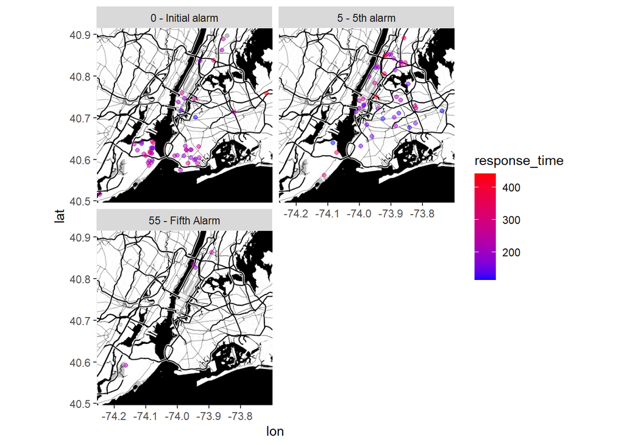

```r
nyc_bb <- c(bottom = 40.49612,
            top = 40.91553,
            left = -74.25559,
            right = -73.70001)

nyc_stamen <- get_stamenmap(bbox = nyc_bb, zoom = 10, maptype = "toner-background")
ggmap(nyc_stamen) +
  geom_point(data = some_building_fires,
             aes(x = lon, y = lat, colour = response_time),
             alpha = 0.5) +
  scale_colour_gradient(low = "blue", high = "red") +
  facet_wrap(~HIGHEST_LEVEL_DESC, ncol = 2)
```

Show a faceted choropleth map indicating how response times have developed over the years. What do you find?

```r
borough_response_time <- full_building_fires %>%
  mutate(year = year(full_building_fires$INCIDENT_DATE_TIME)) %>%
  group_by(BOROUGH_DESC, year) %>%
  summarise(mean_response_time = mean(response_time, na.rm = TRUE))
```

```r
borough_shape <- readOGR("Borough Boundaries/.",
                         "geo_export_c91e0d53-70a6-4c87-b4ce-37705e4ef829") %>%
  spTransform(CRS("+proj=longlat +datum=WGS84")) %>%
  fortify()
borough_shape$id[borough_shape$id == "0"] <- "2 - Bronx"
borough_shape$id[borough_shape$id == "1"] <- "3 - Staten Island"
borough_shape$id[borough_shape$id == "2"] <- "4 - Brooklyn"
borough_shape$id[borough_shape$id == "3"] <- "5 - Queens"
borough_shape$id[borough_shape$id == "4"] <- "1 - Manhattan"

borough_shape <- left_join(borough_shape, borough_response_time, by = c("id" = "BOROUGH_DESC"))
```

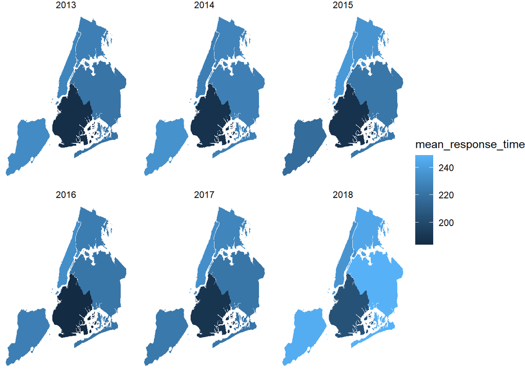

```r
ggplot(borough_shape) +
  geom_polygon(aes(x = long, y = lat, group = group, fill = mean_response_time)) +
  facet_wrap(~year) +
  theme_void()
```

## Submission

Please follow the instructions to submit your homework. The homework is due on Wednesday, March 25.

## Please stay honest!

If you do come across something online that provides part of the analysis / code etc., please no wholesale copying of other ideas. We are trying to evaluate your abilities to visualize data, not the ability to do internet searches. Also, this is an individually assigned exercise – please keep your solution to yourself.